# Лекция 18. Воркшоп: от вопроса до вывода

Блок 5. Честный отчёт

Карен Аванесян

Каузальный анализ в R на данных RLMS-HSE

# Зачем

## Что такое проект

1 причинная оценка на данных RLMS — от вопроса до раздела «Робастность»

10–15 страниц Quarto-отчёта

10 мин защита на занятии 19

- Оценивается не величина эффекта и не его значимость, а **путь**: estimand → DAG → дизайн → допущение → оценка → проверка → вывод с оговоркой
- Нулевой результат с честным дизайном лучше, чем три звёздочки без него

Главный вопрос защиты один: «Что должно быть верно, чтобы ваша оценка была причинной, — и почему вы в это верите?»

## План занятия

1. Карта курса: как выбрать дизайн под вопрос
2. Структура отчёта и шаблон
3. Темы на RLMS с подсказками по дизайну
4. Сквозной пример за 20 минут: «брачная премия»
5. Рубрика и типичные провалы
6. Как делать воспроизводимо

# Идея

## Карта курса: выбор дизайна

| Что у вас есть | Дизайн | Ключевое допущение | Лекции |
| --- | --- | --- | --- |
| Воздействие назначалось случайно | эксперимент, ITT/LATE | рандомизация сработала | 2 |
| Все конфаундеры наблюдаются | регрессия, мэтчинг, IPW, DR | условная независимость | 4–6 |
| Панель; конфаундеры постоянны во времени | FE, event study | строгая экзогенность, нет динамического отбора | 7–8 |
| Группа, которую реформа затронула, и группа, которую нет | DiD, staggered DiD | параллельные тренды | 9–10 |
| Порог по непрерывной переменной | RD, нечёткая RD | непрерывность у порога, нет манипуляции | 11 |
| Переменная, двигающая $D$ и не влияющая на $Y$ иначе | IV | исключение, релевантность, монотонность | 12 |
| Исход наблюдается не у всех (зарплата у работающих) | модель Хекмана | исключающее ограничение, нормальность | 13 |
| Нет ни эксперимента, ни инструмента | AET, Остер, `sensemakr` | граница при допущении о силе отбора | 14, 17 |

Спрашивайте в этом порядке: случайность → наблюдаемые → панель → реформа → порог → инструмент. Чем ниже по таблице, тем сильнее нужна история про **источник вариации**.

## Структура отчёта

| Раздел | Что должно быть | Чего не должно |
| --- | --- | --- |
| 1. Вопрос и estimand | $D$, $Y$, для кого (ATE/ATT/LATE), зачем | «изучить взаимосвязь» |
| 2. DAG | пути, наблюдаемые и ненаблюдаемые, плохие контроли | DAG со всеми переменными датасета |
| 3. Дизайн | допущение словами и почему оно правдоподобно **здесь** | «мы использовали метод X» |
| 4. Данные | волны, выборка, баланс, пропуски | 20 страниц описательных статистик |
| 5. Оценка | интервал, кластеры, график там, где он нужен | 12 колонок с разными контролями |
| 6. Робастность | чувствительность к $U$, спецификации, плацебо | «результат устойчив» |
| 7. Вывод | число с интервалом + условие, при котором оно верно | звёздочки как вывод |

Шаблон: `causal-r/_templates/project-template.qmd` в репозитории курса.

## Темы на RLMS: что можно взять (1)

event study, `sunab`

### Рождение ребёнка и занятость женщин

**Вариация:** первое рождение, панель. **Камень:** динамический отбор: рожают, когда уходят с рынка

RD по возрасту

### Пенсионный возраст и занятость / здоровье

**Вариация:** порог 55/60 (до 2019). **Камень:** ступенчатый возраст в RLMS, кучность

DiD по когортам

### Реформа 2019 и занятость старших

**Вариация:** когорты, не затронутые повышением. **Камень:** другие шоки 2019–2020

регрессия + DR + `sensemakr`

### Высшее образование и зарплата

**Вариация:** диплом. **Камень:** способности; инструмента в RLMS нет

FE + E-value

### Курение и здоровье

**Вариация:** статус курения, панель. **Камень:** обратная причинность: болеют → бросают

## Темы на RLMS: что можно взять (2)

FE, event study

### Переезд в город и зарплата

**Вариация:** смена типа поселения. **Камень:** отбор в переезд по шоку зарплаты

event study

### Брак и зарплата мужчин

**Вариация:** первый брак. **Камень:** отбор по времени: женятся на росте дохода

staggered DiD, `did`

### Региональные ограничения алкоголя

**Вариация:** даты по субъектам. **Камень:** площадка ≠ субъект; мало кластеров

event study по интенсивности

### Антитабачный закон 2013

**Вариация:** до/после, интенсивность. **Камень:** нет контрольной группы — нужна интенсивность

FE + чувствительность

### Интернет дома и зарплата

**Вариация:** появление доступа. **Камень:** обратная причинность, тренд

## Как читать таблицу тем

- Колонка «подводный камень» — главная. Если вы её не чувствуете, это признак, что дизайн не ваш
- Хороший проект — узкий: одна волна/период, одна группа, один исход. «Эффект образования на всё» не защитить
- Любую тему можно сделать на двух уровнях: **(а)** честная оценка при условной независимости + анализ чувствительности; **(б)** квазиэксперимент, если нашлась вариация. (а) с хорошим DAG — достаточно для отличной оценки

# Код

## Сквозной пример: брачная премия

**Вопрос**: повышает ли вступление в брак зарплату мужчин? Классический «marriage premium» — 10–20% в США; споры о том, отбор это или эффект.

- $D$ — первый брак, наблюдаемый в панели (переход «не женат → женат»); $Y$ — log зарплаты; **estimand** — ATT для женившихся, в годы после брака
- Чего мы боимся: мужчины женятся, когда дела идут в гору (отбор по времени), и женятся те, кто и так зарабатывал бы больше (отбор по уровню)
- Дизайн: event study с FE человека (отбор по уровню) и проверкой предтрендов (отбор по времени), лекция 8

## Строим выборку

```r
men <- rlms |> filter(female == 0, age >= 20, age <= 55, !is.na(married)) |>
  arrange(idind, year)
ev <- men |> group_by(idind) |>
  mutate(unmarried_at_start = married[1] == 0,
         trans  = married == 1 & lag(married) == 0,                  # год перехода в брак
         cohort = if (any(trans, na.rm = TRUE)) year[which(trans)[1]]
                  else 10000) |>                                       # 10000 = не женился
  ungroup() |>
  filter(unmarried_at_start, employed == 1, !is.na(log_wage))
ev |> summarise(наблюдений = n(), людей = n_distinct(idind),
                женились = n_distinct(idind[cohort < 10000]),
                `не женились` = n_distinct(idind[cohort == 10000]))
```

| наблюдений | людей | женились | не женились |
| --- | --- | --- | --- |
| 19503 | 3955 | 1303 | 2652 |

Контрольная группа — мужчины, которые в панели так и не женились. Это сильное место и слабое сразу: они не «как женатые до брака», но дают тренд.

## Оценка: event study Sun–Abraham

```r
m_es <- feols(log_wage ~ sunab(cohort, year) + age + I(age^2) | idind + year, ev,
              cluster = ~idind)
summary(m_es, agg = "ATT")$coeftable["ATT", ]                   # средний эффект после брака
```

```
  Estimate Std. Error    t value   Pr(>|t|)
    0.0548     0.0334     1.6420     0.1007
```

```r
m_fe <- feols(log_wage ~ married + age + I(age^2) | idind + year,
              men |> filter(employed == 1), cluster = ~idind)   # обычный FE для сравнения
round(coeftable(m_fe)["married", ], 3)
```

```
  Estimate Std. Error    t value   Pr(>|t|)
     0.065      0.013      5.143      0.000
```

## Динамика

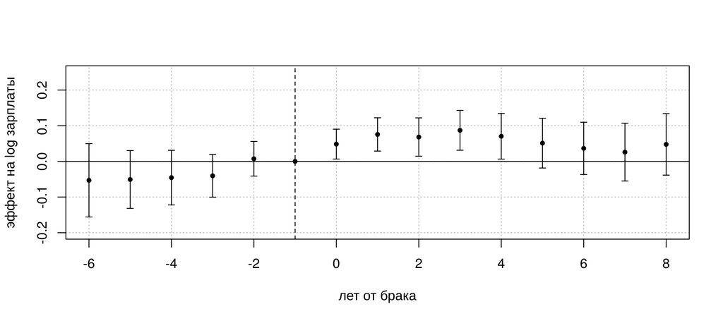

```r
iplot(m_es, ref.line = -1, xlim = c(-6, 8), ylim = c(-0.2, 0.25), main = "",
      xlab = "лет от брака", ylab = "эффект на log зарплаты")
```

## Что мы скажем на защите

- ATT ≈ +5% (от −1% до +12%); обычный FE даёт +6.5% ± 2.5%. Премия есть, но втрое меньше американской, и интервал широк
- Предтренды −5…−3 слегка отрицательны (≈ −0.05, незначимо): намёк на отбор по времени — женятся **после** того, как зарплата пошла вверх. Тогда часть «эффекта» — продолжение тренда
- Робастность: (1) когорты с ≥ 3 годами до брака; (2) плацебо — дата брака на 3 года раньше; (3) `HonestDiD`; (4) гетерогенность: с детьми / без
- Вывод: «брак связан с ростом зарплаты на 5–6% при условии, что без брака она росла бы как у не женившихся; слабый предтренд прижимает нижнюю границу к нулю»

## Рубрика оценивания

вес 15%

### Вопрос и estimand

**Отлично:** $D$, $Y$, популяция, тип эффекта названы и мотивированы. **Неудовлетворительно:** «связь X и Y»

вес 25%

### DAG и допущение

**Отлично:** допущение словами, главный $U$ назван, плохие контроли исключены. **Неудовлетворительно:** DAG ради DAG

вес 25%

### Дизайн и исполнение

**Отлично:** метод соответствует вариации; код чистый; ошибки верные. **Неудовлетворительно:** метод «потому что модный»

вес 20%

### Робастность

**Отлично:** чувствительность к $U$ + плацебо, который мог провалиться. **Неудовлетворительно:** «результат устойчив»

вес 15%

### Вывод и защита

**Отлично:** число, интервал, условие; ответы на вопросы по существу. **Неудовлетворительно:** звёздочки; «значимо = доказано»

## Типичные провалы прошлых проектов

1. Контроль за медиатор «для чистоты» — оценка прямого эффекта выдана за полный
2. DiD без графика предтрендов; RD без графика у порога; IV без first stage
3. Кластеры по человеку там, где воздействие на уровне региона
4. Выборка меняется между таблицами, и никто не заметил
5. Робастность = та же регрессия с другим набором контролей
6. Вывод сильнее, чем дизайн: «образование повышает зарплату на 25%» после регрессии с пятью контролями

## Как читать чужие таблицы: чек-лист

| Где смотреть | Вопрос к таблице | Лекции |
| --- | --- | --- |
| **N и выборка** | Одна ли выборка во всех столбцах? Сколько наблюдений реально работает: в окне RD, у комплаеров? | 4, 11, 12 |
| **Тип ошибок** | Кластеры есть? На уровне назначения воздействия? Сколько кластеров? | 9, 10 |
| **Контроли и FE** | Нет ли медиаторов и «плохих контролей»? Что поглощают FE? | 3, 7 |
| **Ключевой коэффициент** | В каких единицах (лог, п.п., SD)? Какой эстиманд: ATE, ATT, LATE, эффект у порога? | 1, 11, 12 |
| **Диагностика дизайна** | Совместный тест предтрендов; F первой стадии с кластерами; плотность и робастный интервал в RD | 9–12 |
| **Чувствительность** | RV или $\delta$ с понятным бенчмарком; плацебо, которое могло провалиться | 14, 17 |

Если ответа на вопрос в таблице нет — это и есть первый вопрос автору.

## Воспроизводимость

```r
project/
├── project.qmd            # отчёт: текст + код, все цифры из кода
├── R/
│   ├── 01_sample.R        # выборка из rlms_panel.rds -> data/sample.rds
│   ├── 02_estimates.R     # все модели -> output/models.rds
│   └── 03_robustness.R
├── data/                  # только производные файлы, в .gitignore
└── output/                # таблицы и графики
```

- `set.seed()` в начале каждого скрипта; `sessionInfo()` в приложении; `renv::snapshot()` — если проект живёт дольше семестра
- Ни одной цифры в тексте, набранной руками: `r round(coef(m)['D'], 3)`
- Один коммит на законченный шаг; данные RLMS в репозиторий не попадают — только код, который их строит

# Как ошибаются

## Чек-лист перед сдачей

- Вопрос умещается в одно предложение с глаголом «влияет»
- Estimand назван: для кого и какой эффект
- DAG содержит главный ненаблюдаемый конфаундер, и в тексте сказано, что с ним делать
- Ключевое допущение дизайна сформулировано словами, а не названием метода
- Главный результат — одно число с интервалом и графиком, где он уместен
- Анализ чувствительности в понятных единицах; плацебо, который мог провалиться
- Вывод содержит условие «при …»
- Отчёт рендерится с нуля одной командой

# Мини-задача

## К защите

1. Заполните разделы 1–3 шаблона (вопрос, DAG, дизайн и допущение) — **до** любого кода. Пришлите за неделю: получите обратную связь по дизайну, пока не поздно
2. Постройте выборку и таблицу баланса / описательных статистик по группам
3. Основная оценка + один график + один анализ чувствительности
4. Слайды защиты: 8 слайдов, 10 минут — вопрос, DAG, дизайн, данные, результат, робастность, вывод, что бы сделали с идеальными данными

# Литература

## Что прочитать

- Huntington-Klein N. *The Effect* (2022), гл. 22 «Doing Causal Inference» — как собрать всё вместе
- Cunningham S. *Causal Inference: The Mixtape* (2021) — введение: как выбрать дизайн
- Angrist J., Pischke J.-S. *Mastering ’Metrics* (2015), гл. 6 — чек-лист «фурий» для чужих и своих работ
- Lundberg I., Johnson R., Stewart B. (2021). What Is Your Estimand? *ASR* — главная статья для раздела 1
- Gentzkow M., Shapiro J. *Code and Data for the Social Sciences: A Practitioner’s Guide* — воспроизводимость

Каузальный анализ в R · RLMS-HSE · К. Аванесян

← К программе курса